# Introduction to R

# 1 What is R?

R is a free open-source program that is used to do statistics in both academia and industry. There are many online resources for R, for both beginners and experts. For example, [Venables, Smith, and the R Core Team](https://cran.r-project.org/doc/manuals/r-release/R-intro.pdf)

## 1.1 A fancy calculator

R can be used as a fancy calculator

```r
2+2
```

```
## [1] 4
```

```r
sin(3.14)
```

```
## [1] 0.001592653
```

```r
exp(1)
```

```
## [1] 2.718282
```

```r
log(2.71)
```

```
## [1] 0.9969486
```

```r
pi
```

```
## [1] 3.141593
```

Variables can be assigned in the following way

```r
x <- 1+2+3+4+5+6
x*2
```

```
## [1] 42
```

## 1.2 Entering data by hand into R

R is designed to store data as vectors $x = (x_1, x_2, \ldots, x_n)$ that is lists of numbers.

```r
y <- c(1,2,3,4,5,6,7,8,9)
y
```

```
## [1] 1 2 3 4 5 6 7 8 9
```

## 1.3 Basic operations with vectors

R has many built in common operations that are useful for statistics:

```r
x <- c(1,2,3,4,5,6,7,8,9,10)
x
```

```
##  [1]  1  2  3  4  5  6  7  8  9 10
```

```r
sum(x)
```

```
## [1] 55
```

```r
mean(x)
```

```
## [1] 5.5
```

```r
sd(x)
```

```
## [1] 3.02765
```

```r
var(x)
```

```
## [1] 9.166667
```

R will do certain operations component wise:

```r
 x <- c(1,2,3,4,5)
y <- c(6,7,8,9,10)
z=x+y
z
```

```
## [1]  7  9 11 13 15
```

```r
x*y
```

```
## [1]  6 14 24 36 50
```

```r
sin(z)
```

```
## [1]  0.6569866  0.4121185 -0.9999902  0.4201670  0.6502878
```

It is often necessary to add or delete data from a vector:

```r
x<- c(0.1, 0.2, 0.3, 0.4, 0.5)
x <- x[-5]
x
```

```
## [1] 0.1 0.2 0.3 0.4
```

```r
x <- c(x, 5.5)
x
```

```
## [1] 0.1 0.2 0.3 0.4 5.5
```

## 1.4 Coin-flips, dice roll, normal, and uniform random variables in R

R can be used to simulate coin flips and dice roll. R does not use true randomness, rather it generates coin clips using a deterministic algorithm that simulates true randomness.

```r
x<- rbinom(12,1, 0.5)
x
```

```
##  [1] 1 0 1 1 1 0 0 0 0 1 1 0
```

```r
z <- sample(6,12, replace =TRUE)
z
```

```
##  [1] 3 6 1 2 3 5 2 5 6 4 3 3
```

```r
x<- rnorm(10, 5, 1)
x
```

```
##  [1] 5.974917 3.534708 4.859410 4.697788 3.466208 3.913346 4.436586 3.442086
##  [9] 6.308237 6.300232
```

```r
z <- runif(10, min=-1, max=1)
z
```

```
##  [1]  0.34075499  0.17462353  0.46576974 -0.70867034  0.63777496  0.15385946
##  [7] -0.60128102  0.65584384  0.01901222  0.55082952
```

# 2 Histograms in R

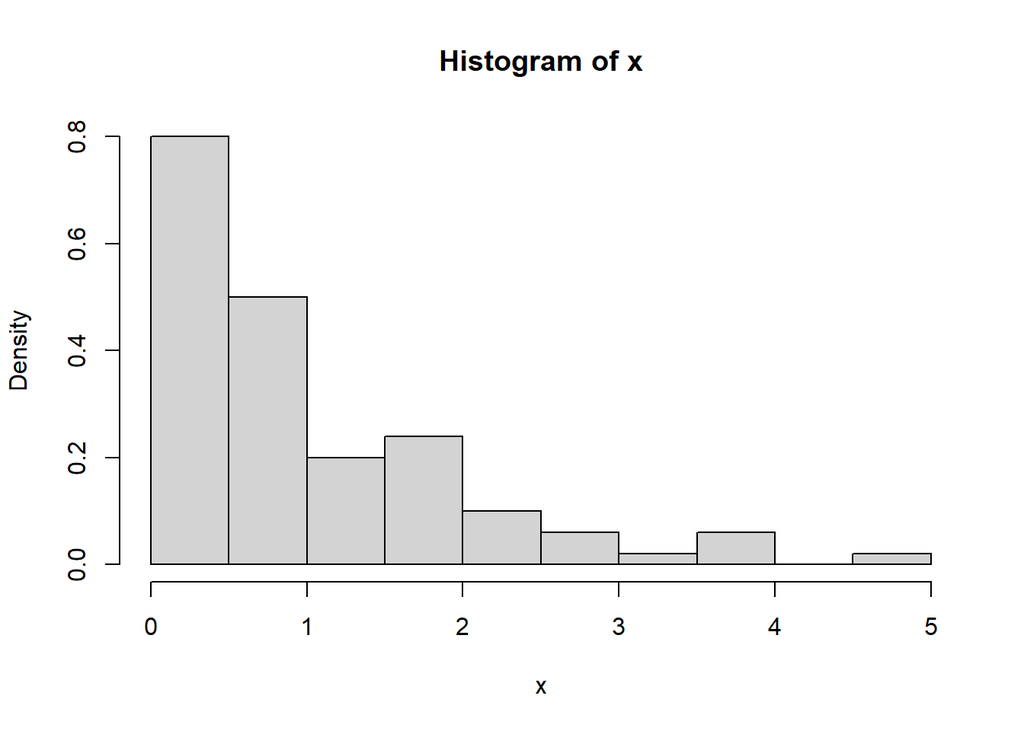

```r
x <- rexp(100,1)
hist(x, prob=TRUE)
```

Here $x$ is a 100 randomly generated data points from the exponential distribution with rate $1$.

# 3 Functions

Suppose we needed to use the quantity $\sin(x) + \cos(x)$ over and over again for different values of $x$, then it may be useful to define this as a function in the following way:

```r
sincos <- function(x){
z <- sin(x) + cos(x);
z
}
sincos(1)
```

```
## [1] 1.381773
```

Here the function sincos takes an input $x$. It is sometimes useful have functions that do not take inputs, but simple perform operations: say roll a fair dice 1o times, and take the sum.

# 4 Basic programming in R

We will introduce basic programming in R with the following exercise and will illustrate how to write a *while* loop in R.

**Exercise 4.1** By running simulations in R, approximate the average number of rolls of a fair dice it takes before you see a 6.

*Solution*. We make a function *numrolls* which counts how many times we need to roll a dice until we see a $6$. Then we use the *replicate* command to repeat this function many time, and take the average.

```r
numrolls <- function(){
n=0
x=0
while(x <6){
x <- sample(6,1, replace =TRUE)
n <- n+1
}
n
}

mean(replicate(1000, numrolls()) )
```

```
## [1] 6.216
```

In the next exercise, we illustrate how to write a *for* loop.

**Exercise 4.2** Define a function that tells you whether a positive integer is prime or not.

*Solution*. Let $n$ be an integer. We first recall that $d$ is a divisor of $n$ if there exists an integer $c$ such that $ n = cd$. An integer $n \geq 2$ is prime if it only divisors are $1$ and $n$. R has a built in remainder function, which for nonnegative integers $a,b$ outputs the remainder in the sense of elementary school, when $a$ is divided by $b$. Using the remainder function we define the *isprime* function, and use it spit out the prime numbers up to 500.

```r
25%%5
```

```
## [1] 0
```

```r
26%%5
```

```
## [1] 1
```

```r
isprime <- function(n){
x=1
for (i in 2: (n-1)){
if (x >0) {
x <- n%%i
}
}
if (n==1) {x <-0}
if (n==2) {x <-1}
 x
 }
 isprime(1)
```

```
## [1] 0
```

```r
 isprime(2)
```

```
## [1] 1
```

```r
isprime(101)
```

```
## [1] 1
```

```r
x=2
 for(i in 3:500){
if( isprime(i)==1){
x <- c(x, i)}
 x
}
x
```

```
##  [1]   2   3   5   7  11  13  17  19  23  29  31  37  41  43  47  53  59  61  67
## [20]  71  73  79  83  89  97 101 103 107 109 113 127 131 137 139 149 151 157 163
## [39] 167 173 179 181 191 193 197 199 211 223 227 229 233 239 241 251 257 263 269
## [58] 271 277 281 283 293 307 311 313 317 331 337 347 349 353 359 367 373 379 383
## [77] 389 397 401 409 419 421 431 433 439 443 449 457 461 463 467 479 487 491 499
```

# 5 Summary

We introduced some basics of R, and we gave examples programming basics including defining functions, while loops, for loops, and using the replicate function.

# 6 Endnotes

- Version: 20 April 2024
- [Rmd Source](https://tsoo-math.github.io/ucl/intro-R.Rmd)